# Mixed effects model lab

Author

Melissa Pulley

## This lab

If you’re able to open the .qmd file on your computer, you can submit the lab that way. That will also make grading easier and faster!

Ideally, try to render it to create an html document. If that’s not working, submit the .qmd file.

If that’s not possible, please submit it as before.

## Walleye and Hg data

Make sure to understand the model structure of a mixed effect model.

We are going to simulate the data. While usually I provide the data, I think it’s important for you to understand how this data is simulated, as it relates to the way the underlying system works.

This is the same example as in the class. We are sampling walleye in Lake Michigan, and are worried about the concentration of Hg and how it relates to length.

We sample four sites and measure length and Hg of all individuals.

#### Regions

In this dataset we have four regions, and we need to generate a random intercept around them:

```r
gamma <- rnorm(n=4,mean=0,sd=0.25)
```

Another random components is the number of individuals caught. The effort was the same in the four sites, and catchability is constant, meaning that they should catch about the same number of individuals.

```r
N<- round(rnorm(4,20,2))
N
```

```
[1] 26 16 20 20
```

#### Simulation

Once we obtain the number of individuals, we will use a random uniform distribution to simulate the number of individuals that were caught.

Finally, the amount of Hg in an individual will be given by:

We will do this four times, and in order to save time, we will do it in a for loop and will save the results in a list

```r
HgDat<-list()
```

Once we created the lists, we can run the simulation:

```r
for(i in 1:4){
  x<-runif(N[i],20,60)
  y<-0.5 + 0.018*x + gamma[i] + rnorm(N[i],0,0.08)
  Region<-rep(LETTERS[i],N[i])
  HgDat[[i]]<-data.frame(size=x,Hg=y,region=Region)
}
```

Check whether the data makes sense. Run HgDat, and you should see four different dataframes, one for each region. There was an easy way to make this into a single dataframe, but lists can be very neat.

In order to have a single dataframe, we can do the following:

```r
HgDat_df<-bind_rows(HgDat)
HgDat_df$region<-as.factor(HgDat_df$region)
```

Now we have an object called HgDat_df with all of the data. Let’s look at it

```r
library(knitr)
library(kableExtra)
library(dplyr)
kbl(HgDat_df, col.names = gsub("[.]", " ", names(HgDat_df)))%>%
  kable_paper() %>%
  scroll_box(width = "500px", height = "200px")
```

| size | Hg | region |
| --- | --- | --- |
| 58.64768 | 1.4883764 | A |
| 57.81684 | 1.3205180 | A |
| 21.09910 | 0.9282367 | A |
| 39.49884 | 1.1484835 | A |
| 28.98235 | 0.8844943 | A |
| 40.80295 | 1.1198705 | A |
| 33.38559 | 1.0510373 | A |
| 33.92628 | 1.1129188 | A |
| 29.20711 | 0.9378816 | A |
| 51.95638 | 1.2939124 | A |
| 52.97708 | 1.4587715 | A |
| 36.15165 | 0.8889966 | A |
| 32.79615 | 0.8799687 | A |
| 34.45786 | 1.1094812 | A |
| 49.79965 | 1.2604188 | A |
| 50.59380 | 1.4109727 | A |
| 57.43883 | 1.5791199 | A |
| 39.62757 | 1.1728167 | A |
| 30.68441 | 0.9655472 | A |
| 56.34523 | 1.4502133 | A |
| 41.09517 | 1.0571139 | A |
| 33.77564 | 1.1277070 | A |
| 53.75838 | 1.4214055 | A |
| 51.98456 | 1.2336360 | A |
| 56.83059 | 1.3592264 | A |
| 20.08503 | 0.8439862 | A |
| 45.87221 | 1.9044506 | B |
| 44.94056 | 1.8643383 | B |
| 59.48532 | 1.9460374 | B |
| 35.01294 | 1.6463935 | B |

[output cut: 52 more lines]

#### Model

In order to run a GLMM with a random intercept, we can use the following code:

```r
library(glmmTMB)
#| warning: False
m1<- glmmTMB(Hg~size + (1|region), data=HgDat_df)

summary(m1)
```

```
 Family: gaussian  ( identity )
Formula:          Hg ~ size + (1 | region)
Data: HgDat_df

     AIC      BIC   logLik deviance df.resid
  -148.4   -138.8     78.2   -156.4       78

Random effects:

Conditional model:
 Groups   Name        Variance Std.Dev.
 region   (Intercept) 0.051936 0.22790
 Residual             0.006796 0.08244
Number of obs: 82, groups:  region, 4

Dispersion estimate for gaussian family (sigma^2): 0.0068

Conditional model:
             Estimate Std. Error z value Pr(>|z|)
(Intercept) 0.6689011  0.1189862   5.622 1.89e-08 ***
size        0.0169982  0.0007674  22.149  < 2e-16 ***
---
Signif. codes:  0 '***' 0.001 '**' 0.01 '*' 0.05 '.' 0.1 ' ' 1
```

**Note**

Are you getting an error about NaN’s found in the data? This is probably caused by the “Matrix” package that followign an upate started adding NAN’s due to a bug. The best solution would be to reinstall the Matrix package independently

Let’s remember our simulated data. Was the model good enough?

Variance individuals and gamma

```r
0.08^2
```

```
[1] 0.0064
```

```r
0.25^2
```

```
[1] 0.0625
```

#### Predictions and plot

Make a prediction data frame

```r
preddata <- HgDat_df
preddata$predHg <- predict(m1, preddata)
```

And plot the model

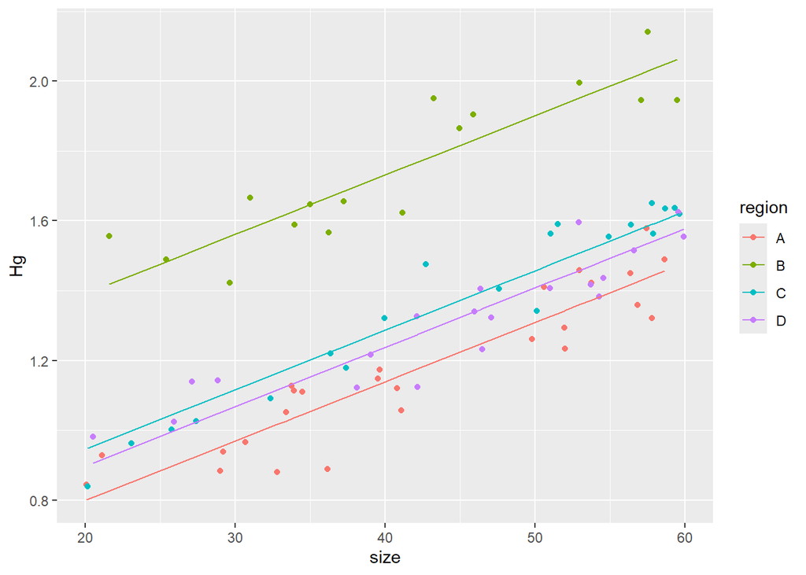

```r
library(ggplot2)
ggplot(data=HgDat_df, aes(x=size, y=Hg, col=region)) +
    geom_point() +
    geom_line(data=preddata, aes(x=size, y=predHg, col=region))
```

#### How to obtain a population “line”

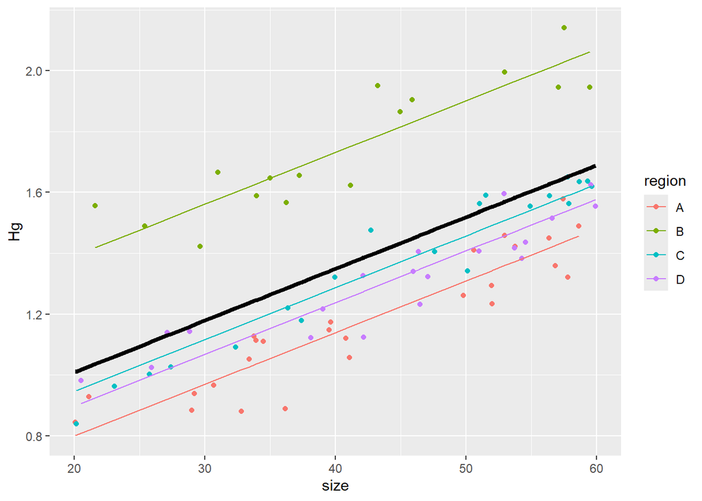

```r
preddata <- HgDat_df
preddata$predHg <- predict(m1, preddata)
preddata$predHg_population <- predict(m1, preddata, re.form=~0)

ggplot(data=HgDat_df, aes(x=size, y=Hg, col=region)) +
    geom_point() +
    geom_line(data=preddata, aes(x=size, y=predHg, col=region))+
  geom_line(data=preddata, aes(x=size, y=predHg_population),                    col='black',linewidth=1.5)
```

Now, let’s repeat this analysis, but in this case, let’s assume the intercept is fixed, and the slope is random

**Question 1: points:10**

Simulate the same study, but in this case, there is a fixed intercept and a random slope. 1) Present the equation you used for the simulation (similar to the equation I showed in this document). 2) Run the mixed-effects model, 3) Report whether the model output was a good representation of reality, and 4) plot your model

We have the model with fixed intercept and random slope

```r
psi <- rnorm(n=4,mean=0,sd=0.25)
gamma <- 0
N<- round(rnorm(4,20,2))

HgDat<-list()

for(i in 1:4){
  x<-runif(N[i],20,60)
  y<-0.5 + (0.018+psi[i])*x + gamma + rnorm(N[i],0,0.08)
  Region<-rep(LETTERS[i],N[i])
  HgDat[[i]]<-data.frame(size=x,Hg=y,region=Region)
}

HgDat_df<-bind_rows(HgDat)
HgDat_df$region<-as.factor(HgDat_df$region)

kbl(HgDat_df, col.names = gsub("[.]", " ", names(HgDat_df)))%>%
  kable_paper() %>%
  scroll_box(width = "500px", height = "200px")
```

| size | Hg | region |
| --- | --- | --- |
| 34.40949 | 9.0312577 | A |
| 47.41636 | 12.5141475 | A |
| 23.61786 | 6.4384837 | A |
| 50.65162 | 13.1436338 | A |
| 32.36202 | 8.5409073 | A |
| 37.95684 | 10.0099492 | A |
| 22.66130 | 6.1498528 | A |
| 55.55838 | 14.4413457 | A |
| 43.52904 | 11.5102378 | A |
| 31.45567 | 8.4668383 | A |
| 51.43306 | 13.3937487 | A |
| 30.64244 | 8.2223473 | A |
| 49.46138 | 12.9352216 | A |
| 30.06099 | 8.0545090 | A |
| 30.10904 | 8.1119534 | A |
| 34.06851 | 9.0083504 | A |
| 45.73987 | 11.8968143 | A |
| 20.01467 | 5.4994793 | A |
| 29.05097 | -1.1430949 | B |
| 46.19125 | -1.9076272 | B |
| 34.50155 | -1.5253732 | B |
| 47.06259 | -2.1867950 | B |
| 32.68091 | -1.4606034 | B |
| 30.30448 | -1.2013100 | B |
| 26.07091 | -0.8868039 | B |
| 44.59457 | -1.9989675 | B |
| 58.89734 | -2.8325432 | B |
| 26.53682 | -0.9716793 | B |
| 40.80053 | -1.6901359 | B |
| 35.71507 | -1.4516902 | B |

[output cut: 52 more lines]

```r
m2<- glmmTMB(Hg~size + (0+size|region), data=HgDat_df)


summary(m2)
```

```
 Family: gaussian  ( identity )
Formula:          Hg ~ size + (0 + size | region)
Data: HgDat_df

     AIC      BIC   logLik deviance df.resid
  -142.9   -133.3     75.5   -150.9       78

Random effects:

Conditional model:
 Groups   Name Variance Std.Dev.
 region   size 0.044419 0.21076
 Residual      0.005052 0.07108
Number of obs: 82, groups:  region, 4

Dispersion estimate for gaussian family (sigma^2): 0.00505

Conditional model:
            Estimate Std. Error z value Pr(>|z|)
(Intercept)  0.48395    0.02823  17.142   <2e-16 ***
size        -0.08032    0.10538  -0.762    0.446
---
Signif. codes:  0 '***' 0.001 '**' 0.01 '*' 0.05 '.' 0.1 ' ' 1
```

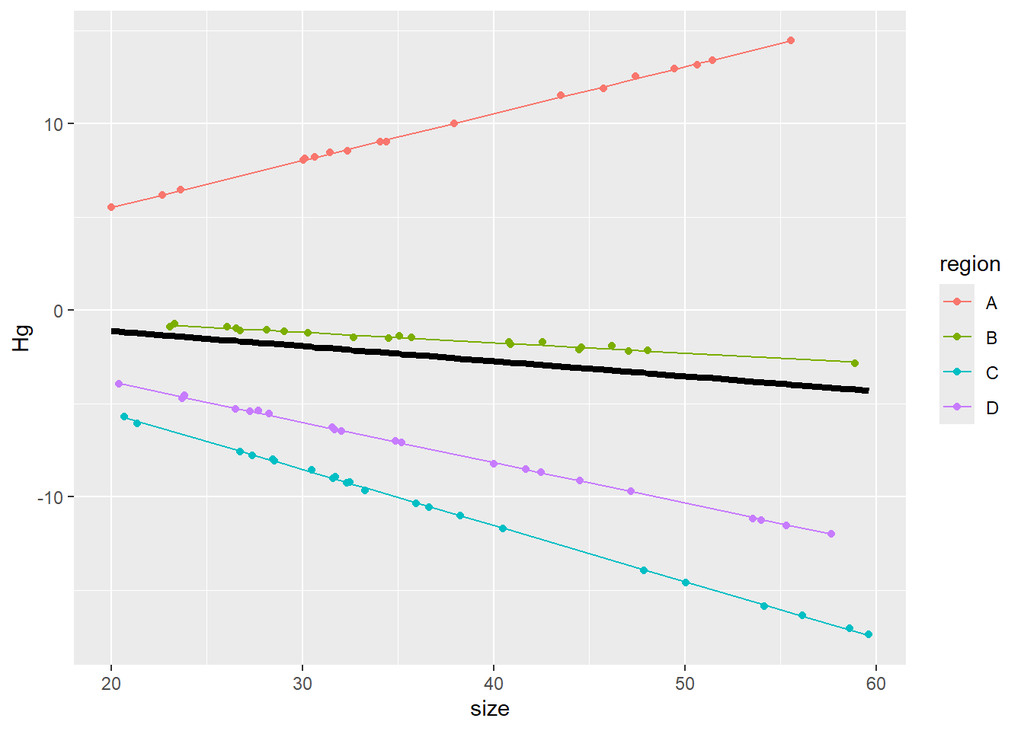

```r
preddata <- HgDat_df
preddata$predHg <- predict(m2, preddata)

preddata <- HgDat_df
preddata$predHg <- predict(m2, preddata)
preddata$predHg_population <- predict(m2, preddata, re.form=~0)

ggplot(data=HgDat_df, aes(x=size, y=Hg, col=region)) +
    geom_point() +
    geom_line(data=preddata, aes(x=size, y=predHg, col=region))+
  geom_line(data=preddata, aes(x=size, y=predHg_population),col='black',linewidth=1.5)
```

## Answer 1.

**Question 2. Points: 10**

Simulate the same study, but in this case, there is a random intercept and a random slope. 1) Present the equation you used for the simulation (similar to the equation I showed in this document). 2) Run the mixed-effects model, 3) Report whether the model output was a good representation of reality, and 4) plot your model

```r
psi <- rnorm(n=4,mean=0,sd=0.25)
gamma <- rnorm(n=4,mean=0,sd=0.25)
N<- round(rnorm(4,20,2))

HgDat<-list()


for(i in 1:4){
  x<-runif(N[i],20,60)
  y<-0.5 + (0.018+psi[i])*x + gamma[i] + rnorm(N[i],0,0.08)
  Region<-rep(LETTERS[i],N[i])
  HgDat[[i]]<-data.frame(size=x,Hg=y,region=Region)
}

HgDat_df<-bind_rows(HgDat)
HgDat_df$region<-as.factor(HgDat_df$region)

kbl(HgDat_df, col.names = gsub("[.]", " ", names(HgDat_df)))%>%
  kable_paper() %>%
  scroll_box(width = "500px", height = "200px")
```

| size | Hg | region |
| --- | --- | --- |
| 43.57893 | -13.2313652 | A |
| 38.12684 | -11.5418181 | A |
| 58.38926 | -17.8432748 | A |
| 34.33527 | -10.3969089 | A |
| 27.22175 | -8.0008255 | A |
| 54.35362 | -16.6858961 | A |
| 53.16094 | -16.0831850 | A |
| 50.12350 | -15.1484617 | A |
| 37.59326 | -11.2082792 | A |
| 39.95244 | -12.1214533 | A |
| 41.96360 | -12.8302051 | A |
| 36.89218 | -11.0515739 | A |
| 50.30474 | -15.2769984 | A |
| 43.76013 | -13.4315503 | A |
| 20.19677 | -5.7958804 | A |
| 50.54671 | -15.3651853 | A |
| 28.77338 | -8.4614407 | A |
| 51.71578 | 22.9979957 | B |
| 42.34432 | 18.7967506 | B |
| 53.46521 | 23.7563130 | B |
| 31.17501 | 13.7023537 | B |
| 49.58935 | 22.0405518 | B |
| 56.69232 | 25.1425271 | B |
| 57.91264 | 25.7694936 | B |
| 56.78558 | 25.1851673 | B |
| 28.92572 | 12.9288525 | B |
| 56.67487 | 25.1580760 | B |
| 53.76245 | 24.0069428 | B |
| 38.83901 | 17.3014128 | B |
| 55.93722 | 24.8268304 | B |

[output cut: 51 more lines]

```r
m3<- glmmTMB(Hg~size + (1 + size|region), data=HgDat_df)

summary(m3)
```

```
 Family: gaussian  ( identity )
Formula:          Hg ~ size + (1 + size | region)
Data: HgDat_df

     AIC      BIC   logLik deviance df.resid
  -105.0    -90.7     58.5   -117.0       75

Random effects:

Conditional model:
 Groups   Name        Variance Std.Dev. Corr
 region   (Intercept) 0.090777 0.30129
          size        0.074597 0.27312  -0.80
 Residual             0.006576 0.08109
Number of obs: 81, groups:  region, 4

Dispersion estimate for gaussian family (sigma^2): 0.00658

Conditional model:
            Estimate Std. Error z value Pr(>|z|)
(Intercept)  0.32671    0.15442   2.116   0.0344 *
size         0.02466    0.13656   0.181   0.8567
---
Signif. codes:  0 '***' 0.001 '**' 0.01 '*' 0.05 '.' 0.1 ' ' 1
```

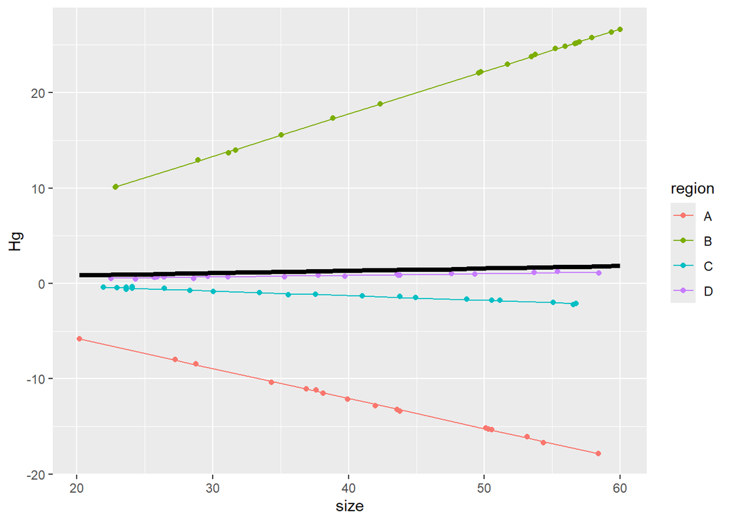

```r
preddata <- HgDat_df
preddata$predHg <- predict(m3, preddata)
preddata$predHg_population <- predict(m3, preddata, re.form=~0)

ggplot(data=HgDat_df, aes(x=size, y=Hg, col=region)) +
    geom_point() +
    geom_line(data=preddata, aes(x=size, y=predHg, col=region))+
  geom_line(data=preddata, aes(x=size, y=predHg_population),                    col='black',linewidth=1.5)
```

## Answer 2

You will repeat question 2, but using the following to obtain your sample:

## Question 3

```r
psi <- rnorm(n=4,mean=0,sd=0.25)
gamma <- rnorm(n=4,mean=0,sd=0.25)
N<- round(rnorm(4,150,20))

HgDat<-list()


for(i in 1:4){
  x<-runif(N[i],20,60)
  y<-0.5 + (0.018+psi[i])*x + gamma[i] + rnorm(N[i],0,0.08)
  Region<-rep(LETTERS[i],N[i])
  HgDat[[i]]<-data.frame(size=x,Hg=y,region=Region)
}

HgDat_df<-bind_rows(HgDat)
HgDat_df$region<-as.factor(HgDat_df$region)

kbl(HgDat_df, col.names = gsub("[.]", " ", names(HgDat_df)))%>%
  kable_paper() %>%
  scroll_box(width = "500px", height = "200px")
```

| size | Hg | region |
| --- | --- | --- |
| 56.92213 | 1.6536118 | A |
| 51.25014 | 1.5796879 | A |
| 52.55957 | 1.7190252 | A |
| 52.57950 | 1.6091900 | A |
| 27.99638 | 1.0258610 | A |
| 42.10113 | 1.3147671 | A |
| 53.40427 | 1.8209518 | A |
| 20.03227 | 0.7330632 | A |
| 30.43893 | 1.0741011 | A |
| 44.25375 | 1.3713322 | A |
| 58.73102 | 1.8845422 | A |
| 52.22318 | 1.5303283 | A |
| 51.47078 | 1.7279826 | A |
| 28.29215 | 1.0222488 | A |
| 58.16276 | 1.8226761 | A |
| 24.96606 | 1.0005577 | A |
| 20.34482 | 0.8753185 | A |
| 56.59080 | 1.6551331 | A |
| 53.64121 | 1.6707653 | A |
| 21.14510 | 0.8649717 | A |
| 38.70180 | 1.3323085 | A |
| 42.52702 | 1.5306883 | A |
| 56.38350 | 1.8392617 | A |
| 34.10526 | 1.1769470 | A |
| 25.92927 | 1.0195413 | A |
| 54.26420 | 1.5890764 | A |
| 27.20729 | 1.0802624 | A |
| 36.90442 | 1.3446735 | A |
| 35.12877 | 1.1972210 | A |
| 39.66447 | 1.4392940 | A |

[output cut: 569 more lines]

```r
m4<- glmmTMB(Hg~size + (1+size|region), data=HgDat_df)

summary(m4)
```

```
 Family: gaussian  ( identity )
Formula:          Hg ~ size + (1 + size | region)
Data: HgDat_df

     AIC      BIC   logLik deviance df.resid
 -1281.0  -1254.6    646.5  -1293.0      593

Random effects:

Conditional model:
 Groups   Name        Variance Std.Dev. Corr
 region   (Intercept) 0.023209 0.15234
          size        0.013408 0.11579  0.33
 Residual             0.006039 0.07771
Number of obs: 599, groups:  region, 4

Dispersion estimate for gaussian family (sigma^2): 0.00604

Conditional model:
            Estimate Std. Error z value Pr(>|z|)
(Intercept)  0.45973    0.07708   5.964 2.45e-09 ***
size        -0.09162    0.05790  -1.582    0.114
---
Signif. codes:  0 '***' 0.001 '**' 0.01 '*' 0.05 '.' 0.1 ' ' 1
```

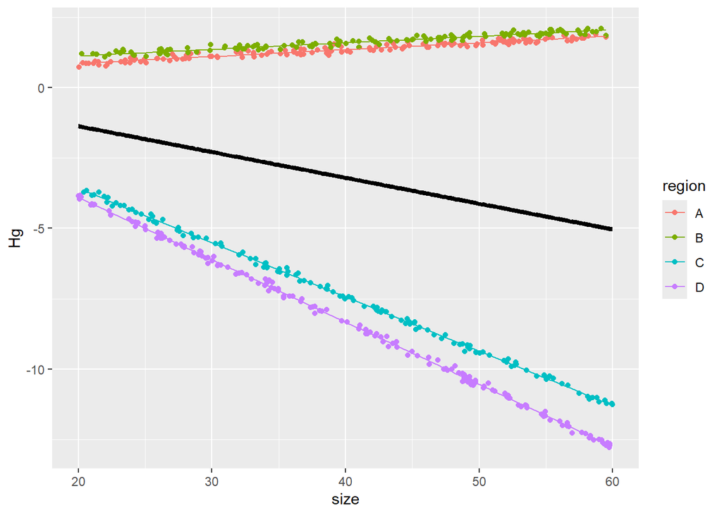

```r
preddata <- HgDat_df
preddata$predHg <- predict(m4, preddata)
preddata$predHg_population <- predict(m4, preddata, re.form=~0)

ggplot(data=HgDat_df, aes(x=size, y=Hg, col=region)) +
    geom_point() +
    geom_line(data=preddata, aes(x=size, y=predHg, col=region))+
  geom_line(data=preddata, aes(x=size, y=predHg_population),                    col='black',linewidth=1.5)
```

## Answer 3

**Question 3. Points:4**

Total points: 24

Resources:

ggplot cheat sheet: https://github.com/rstudio/cheatsheets/blob/main/data-visualization.pdf